# Replication of ‘Spontaneous Hedonic Reactions to Social Media Cues’ by van Koningsbruggen, Eden, & Veling (2017, Cyberpsychology, Behavior, & Social Networking)

Angela Lee (angela8@stanford.edu)

November 25, 2020

## Introduction

Link to full repo: https://github.com/psych251/vanKoningsbruggen2017.git

This project is a replication of empirical research by van Koningsbruggen et al (2017). The original research was published in Cyberpsychology, Behavior, and Social Networking.

In the field of social media research, many have wondered about why it may be challenging to resist the pull of using social media - such as wanting to open a notification when we see it pop up on our screen. However, while it is well-documented that many may find it challenging to resist the desire to engage with social media when the opportunity is presented to us, much less is known about the psychological mechanisms that underlie this finding.

Van Koningsbruggen et al. explore one possible mechanism for this by examining whether people have strong, spontaneous hedonic reactions to social media cues by using an online implicit measure of affective reactions called the Affect Misattribution Procedure. More specifically, the particular result I am interested in replicating is their mediation finding, where they found a significant indirect effect of Facebook use (frequency) on Facebook cravings by hedonic reactions to Facebook (vs. control) cues. In other words, that more-frequent Facebook users would experience stronger and more positive hedonic reactions to social media cues presented in the AMP measure, that were partially mediated through self-reported craving of social media. Overall, their findings are interesting and relevant to the literature because they explore the role of affect and affective reactions in the context of social media use.

## Project Proposal

Justification: My current research program focuses on how beliefs and responses to social technologies such as social media are related to health and psychological well-being. Up until now, my work has focused on understanding the mindsets that people have about social media, such as whether they believe it is an enhancing and beneficial tool they can utilize effectively or whether they believe it is a harmful and influential addiction. Currently, I’m very interested in understanding how social media use interacts with emotional responses. I selected Study 2 from van Koningsbruggen et al. (2017) because it examines the emotional associations that frequent vs. infrequent Facebook users have about social media through an online paradigm that captures spontaneous affective responses. More specifically, the particular result I am interested is their mediation finding a significant indirect effect of Facebook use (frequency) on Facebook cravings by hedonic reactions to Facebook (vs. control) cues. As the next step in my own research program, I’m hoping to examine how people with different mindsets of social media use respond emotionally to social media cues. I believe that replicating this study will help me better develop the skills necessary to program such an online paradigm and advance my understanding of hedonic reactions to social media cues.

Description: Study 2 recruited 170 participants from Amazon mTURK, who were paid $1 each for their time (128 in final analysis). Participants were required to have a 95% mTURK approval rating. Exclusion criteria were: (1) Participants must be Facebook users, (2) not be familiar with the Chinese or Japanese language (characters are used in the paradigm), and (3) sufficient engagement with the task (i.e., not ‘straightlining’ their AMP paradigm responses).

Participants were told they were going to complete a task “examining how people make judgements under distracting conditions.” They were randomly assigned to seeing social media cues as primes (i.e., Facebook Logo, screenshot of timeline) or a control condition showing them photos of office supplies. This task was the “Affect Misattribution Procedure”, an implicit measure of affective reactions. There are 60 trials (w/ 10 practice trials) of the AMP procedure, where participants (1) see a prime picture (social media cue or office supply) for 75 ms, (2) see a blank screen for 125 ms, (3) see a Chinese ‘pictograph’ character for 100 ms, and a (4) mask image. Participants respond whether each prime is more or less pleasant than the ‘pictograph’ character. The dependent variable of hedonic reaction consists of participants’ average ratings of pleasantness of social media-related cues. Participants were also asked to complete a six-item measure of Facebook cravings (i.e., “I want to use Facebook right now.”).

Potential challenges I anticipate with this study revolve around programming and questions of stimuli validity. Although I want to use this project as a learning opportunity on how to code online paradigms and use implicit measures paradigms, I have not done this before and anticipate possible programming challenges. In addition, I have some questions about the stimuli. They are available via supplemental materials provided by the original team, but I worry that the social-media cues (i.e., screenshot of Facebook timeline) may now be outdated and may influence participants’ responses. Finally, I have some concerns that the use of Chinese ‘pictograph’ characters in the original AMP paradigm will result in a systematic exclusion of Asian or Asian American participants. I am not sure of the best way to proceed with this.

## Methods

### Power Analysis

Following the project power guidance from PSYCH251’s lecture, I wanted to try to find the key test and determine if we could compute ES. The primary test was a mixed model repeated measures ANOVA on hedonic reactions with cue type (FB vs. control) as the within subject factor and standardized Facebook use as the continuous predictor. According to the original study, “The main effects of cue type, F(1, 126) = 2.28, p = 0.134, and g2p = 0.018, or Facebook use, F(1, 126) = 0.26, p = 0.609, and g2p = 0.002, were not significant. However, the results again revealed a significant interaction effect between cue type and Facebook use, F(1, 126) = 8.91, p = 0.003, and g2p = 0.066 (Fig. 2B). Simple effects tests showed that frequent Facebook users had significantly more pleasant responses following Facebook cues (M = 0.64, SE = 0.03) than control cues (M=0.52, SE=0.03), Mdifference=0.12, SEdifference= 0.04, 95% CI = [0.05, 0.20], F(1, 126) = 10.70, p = 0.001, and g2p = 0.078.” The partial-eta-squared was the effect size, which was 0.078.

Based on this, I used GPower of ANOVA repeated-measures with within-between interaction to calculate the necessary sample size. [*NOTE: I wasn’t 100% sure if this was the right GPOWEr test to enter vs. a repeated measures ANOVA of within factors*] The number of groups was set to 2 (FB vs. control cues) and the number of measurements was 10 (for the # of trials). However,I did not know the correlation value between the repeated measures so I left it at 0.5, which was the default setting in GPOWER. According to this, I would need a sample size of 196 participants to achieve 95% power.

### Planned Sample

All participants will be recruited from Amazon mechanical Turk. The original study recruited 92 participants in Study 1 and 170 participants in Study 2.

Our pre-selection criteria will ask for mTurkers to have a (1) 95% mTurk approval rating, (2) be located in the United States, and (3) have successfully completed at least 50 mTurk tasks. After data collection but before data analysis, we will exclude participants based on the following a priori criteria from the original article: (1) If participants have already done a study using the Affective Misattribution Procedure, (2) If participants do not use Facebook, (3) If participants are familiar with / fluent in the Chinese or Japanese language, (4) If participants respond to every target in the AMP with the same response key.

We will not target or limit our participant criteria according to any demographics.

### Materials

The following was quoted from the original article and followed precisely. Exceptions are described below.

“For the AMP, we selected 10 Facebook-related (e.g., the Facebook logo, a timeline screenshot) and 10 control pictures of office supplies (e.g., a stapler and sticky tape) as primes, supplemented with a filler picture (10 times a grey square). The Chinese pictographs and mask picture were taken from the materials used by Payne et al.”

These stimuli were pretested in the original article to confirm that participants would rate the Facebook-related and control cues as equally appealing.

The one difference we wanted to note here is that we changed two of the Facebook-related cues (#8 and #9). The reason for this is that one utilized an outdated image of the Facebook newsfeed and the other was in a non-English language. We wanted to change these stimuli to make it more aligned with the newest Facebook interface and fit to our English-speaking sample.

“Hedonic reactions. Following Payne et al.,14 on each trial of the AMP, a prime picture was presented (75 ms), followed by a blank screen (125 ms), a Chinese pictograph (100 ms), and finally a mask that remained until a response was made (Fig. 1). Participants were asked to judge whether each pictograph was more or less pleasant than the average pictograph using the ‘‘i’’ ( pleasant) and ‘‘e’’ (unpleasant) keys. The task consisted of 60 trials (preceded by 10 practice trials), presented in random order. Each prime picture was shown twice and was paired with a new pictograph each time.”

[figure not shown]

figure of hedonic reaction AMP task.

“Facebook cravings. In Study 2, Facebook cravings were measured using six items (a = 0.94) based on22: ‘‘I want to use Facebook right now,’’ ‘‘I would love if it was possible to use Facebook right now,’’ ‘‘I will use Facebook immediately after I finished this survey,’’ ‘‘I strongly desire to use Facebook right now,’’ ‘‘I don’t need Facebook at the moment’’ (reverse scored), and ‘‘Right now, I am craving to use Facebook.’’ Responses were given on a 5-point scale (1 = strongly disagree, 2 = disagree, 3 = neutral, 4 = agree, and 5 = strongly agree).”

“Facebook use. Facebook use was assessed with items measuring the duration and frequency of use and were adapted from Ross et al.,23 and supplemented with an additional item (‘‘How often do you check your Facebook account?’’).” Items measuring the frequency of Facebook use were standardized as Z-scores.

### Procedure

We will replicate the methods of the original study as closely as possible. We will recruit participants from Amazon mechanical Turk; We will consult the original authors for the name they gave to their HIT and use the same.

“Facebook users’ spontaneous hedonic reactions were assessed using the AMP with cue type (Facebook vs. control) as within-subjects factor and Facebook use as continuous predictor. MTurk participants (N= 92 and 170 in Studies 1 and 2, respectively) from the United States who had at least a 95% MTurk approval rating and successfully completed 50 MTurk tasks before completed the online study (programmed in Inquisit 4) and were paid $1. Based on a priori criteria and before any data analyses, participants were excluded if they already participated in a study using the same AMP (n = 5 and 13 in Studies 1 and 2, respectively), did not use Facebook (n = 11 and 18 in Studies 1 and 2, respectively), were familiar with the Chinese or Japanese language (which may influence their AMP responses,14 n = 5 in both studies), or responded to every target in the AMP with the same response key14 (n = 1 and 11 in Studies 1 and 2, respectively). Thus, analyses were conducted on 72 and 128 participants in Studies 1 and 2, respectively (some participants met multiple exclusion criteria). Participants first completed the AMP (presented as a task examining how people make judgments under distracting conditions), followed by a questionnaire that included the Facebook cravings (in Study 2 only) and Facebook use measures. After answering some background and demographic questions (see Table 1 for the samples’ characteristics), they were thanked for their participation.”

### Analysis Plan

Participants were excluded according the a priori criteria specified.

Data cleaning will proceed as follows. Notes where I am uncertain and would like to clarify in author contact email are marked with a *.

Hedonic reactions will be calculated for each participant through the AMP data*. The original paper notes that they examine the “mean proportion of pleasant responses to Facebook cues” and the “mean proportion of pleasant responses to control cues.” My working plan at the moment to get this number is by (1) extracting and downloading participant response data from Inquisit & Qualtrics, (2) for each participant, identify their responses to the Facebook cues vs.the Control cues, (3) label a “pleasant” response (i-key) to each cue as a 1 and an “un-pleasant” response (e-key) as a 0, (4) for each participant, take the mean of their responses to Facebook-related cues and take the mean of their responses to Control cues.

The continuous variable of “Facebook use” will be standardized due to differing scale ranges. We will compute the median and mean* of “Facebook duration” and frequency.

I am a little confused about the right way to take the mean of non-interval ordinal data for “Facebook duration” and “frequency of Facebook use.” The original study notes that the response categories were e.g. (1 = 10 minutes, 2 = 10-30 mins, 3 = 31-60 mins, 4 = 1-2 hours). However, I’m unsure about how to interpret the mean in this case. The table 2 summary also reports the median response of duration and frequency. Final report update: The Facebook duration measure was not used in the key analyses tested below.

Once data is cleaned, we will follow the analyses in the original Study 2: (1) Run bivariate correlations between mean proportion of pleasant responses to FB cues, mean proportion of pleasant responses to control cues, Facebook use, and Facebook cravings. (2) Run a mixed-model repeated-measures ANOVA on hedonic reactions with cue type as the within subjects factor (prop. of pleasant responses to FB cues, prop. of pleasant response to control cues) on standardized Facebook use as a continuous predictor. (3) Use simple effects tests to see if frequent Facebook useres have more pleasant responses following FB cues than following control cues. (4) Run a mediation model using PROCESS macro Model 4 in SPSS. AMP responses were scored as a difference score by subtracting proportion of pleasant responses to control cues from proportion of pleasant responses to FB cues (higher scores mean more positive responses to FB cues relative to control cues). Facebook use will be entered as the predictor, AMP difference score as indirect mediation, and Facebook cravings will be the dependent variable.

### Differences from Original Study

There were several notable differences between the original study and the replication.

1. First, we have slightly modified two of the image stimuli from the AMP paradigm to be more reflective of our participants’ language and the updated FB interface. Failing to update these stimuli (ex. of the Facebook newsfeed) to the current appearance may have influenced participants’ responses because of the potential for distraction involved in noting the difference between ‘old’ images (ex. the old Facebook logo) and current aesthetics. We do not expect this to make any difference in the findings because of the minimal change to the stimuli.
2. Second, we coded and implemented the task in Qualtrics using Javascript (MinnoJS software) instead of Inquisit software. The prohibiting factor of using Inquisit to most accurately replicate the original experiment was the cost of purchasing the Inquisit software license for use in this replication; the free trial of Inquisit does not allow data to be collected from third-party sites like mTurk. As a result, we chose to implement the task in Javascript trying to match the original AMP as closely as possible. The same number of images were displayed for the same length of time, with the same instructions and user-interface as the original study. While there may be some aesthetic differences between the Inquisit task and the Qualtrics Javascript version (size of text, font type), we do not anticipate this to affect the results in a meaningful way.
3. Third, data from the original study included a series of other scales and measures (i.e., a measure of cyber-loafing) that were reported in the supplement but not the main paper. Because these measures were not relevant to the primary analyses of interest, we did not include them in our replication. It is difficult to know whether not including these additional measures will influence the key analyses; however, if the effect holds, the results of the key analyses should not be influenced by the non-inclusion of these additional measures.
4. Fourth, data cleaning and analysis was conducted in SPSS for the original study and in R for the replication. The reason for this was because SPSS is also a paid software and the goals of the PSYCH251 course were to replicate using R. We do not anticipate this will affect the results of the study, but note that there are slight changes in procedure in data cleaning in line with translating SPSS syntax to R.

There were no differences in sample (mTurk participants for both original and replication).

### Methods Addendum (Post Data Collection)

#### Actual Sample

> The sample size was 60 participants recruited from Amazon mechanical Turk. We removed 4 participants who did not finish the entire study; no participants needed to be excluded for language and social media use criteria. The average age of our sample was 40.2 years old. 41.7% of the participants were female and 58.4% were male.

#### Differences from pre-data collection methods plan

> One difference was collecting data from a sample size of 60 participants. Although our original power analysis would have wanted an ideal number of 196 participants for sufficient power at the 95% level, we needed to consider budgetary restrictions and thus collected 60 participants.

## Results

### Data preparation: Final write-up

```r
####Load Relevant Libraries and Functions

library(tidyverse)
```

```r
library(readr)
library(knitr)
library(ggplot2)

####Import data

setwd("/Users/Angela/Desktop/vanKoningsbruggen2017/")
df.final = read.csv('PSYCH251_SM_AMP_Cleaned_WithoutIdentifying.csv', header = TRUE, stringsAsFactors = FALSE)

#### Data exclusion / filtering

df.final_exc <- df.final %>%
  filter(Q13 == "2") %>% #exclude participants familiar w/ Chinese / Japanese lang
  filter(Q12 == "1") %>%  #exclude participants who don't have FB
  filter(Finished == "1") #exclude participants who didn't finish

#### Prepare data for analysis - create columns etc.
# This is translated for R from the OSF SPSS syntax from the original study [https://osf.io/9gue3/]

df.final_clean <- df.final_exc %>%
  rename(chinese_lang = Q12,
         fb_use_screen = Q13,
         amp_fulltext = Q25,
         fb_use_dur = Q3,
         fb_use1 = Q6,
         fb_use2 = Q7,
         fb_use3 = Q8,
         fb_use4 = Q9,
         fb_use5 = Q10,
         fb_use6 = Q11,
         craving1 = Q15,
         craving2 = Q19,
         craving3 = Q20,
         craving4 = Q21,
         craving5 = Q17,
         craving6 = Q18,
         age = Q22,
         gender = Q23) %>%
  rowwise() %>%

  #compute composite vars
  mutate(fb_use_mean = mean(c(fb_use1, fb_use2, fb_use3, fb_use4, fb_use5, fb_use6))) %>%

  #compute mean of all gen media use
   mutate(cravings_mean = mean(c(craving1, craving2, craving3, craving4, craving5, craving6))) %>%
  mutate(propFB = amp_sm_pleasant / 30) %>%
  mutate(propCon = amp_c_pleasant / 30) %>%

  #compute AMP diff score for med. analysis
  mutate(amp_diff = propFB - propCon)
```

[output not shown]

[output cut: 124 more lines]

[output not shown]

[output not shown]

[output cut: 124 more lines]

[output not shown]

```r
  #turn all factor vars into numerics

  df.final_clean$Finished <- as.numeric(df.final_clean$Finished)
  df.final_clean$fb_use1 <- as.numeric(df.final_clean$fb_use1)
  df.final_clean$fb_use2 <- as.numeric(df.final_clean$fb_use2)
  df.final_clean$fb_use3 <- as.numeric(df.final_clean$fb_use3)
  df.final_clean$fb_use4 <- as.numeric(df.final_clean$fb_use4)
  df.final_clean$fb_use5 <- as.numeric(df.final_clean$fb_use5)
  df.final_clean$fb_use6 <- as.numeric(df.final_clean$fb_use6)
  df.final_clean$fb_use_dur <- as.numeric(df.final_clean$fb_use_dur)
  df.final_clean$craving1 <- as.numeric(df.final_clean$craving1)
  df.final_clean$craving2 <- as.numeric(df.final_clean$craving2)
  df.final_clean$craving3 <- as.numeric(df.final_clean$craving3)
  df.final_clean$craving4 <- as.numeric(df.final_clean$craving4)
  df.final_clean$craving5 <- as.numeric(df.final_clean$craving5)
  df.final_clean$craving6 <- as.numeric(df.final_clean$craving6)
  df.final_clean$age <- as.numeric(df.final_clean$age)
  df.final_clean$gender <- as.numeric(df.final_clean$gender)

  #standardize fb_use
  df.final_clean$ztest_fb_use1 <- ((df.final_clean$fb_use1 - mean(df.final_clean$fb_use1)) / sd(df.final_clean$fb_use1))
  df.final_clean$ztest_fb_use2 <- ((df.final_clean$fb_use2 - mean(df.final_clean$fb_use2)) / sd(df.final_clean$fb_use2))
   df.final_clean$ztest_fb_use3 <- ((df.final_clean$fb_use3 - mean(df.final_clean$fb_use3)) / sd(df.final_clean$fb_use3))
   df.final_clean$ztest_fb_use4 <- ((df.final_clean$fb_use4 - mean(df.final_clean$fb_use4)) / sd(df.final_clean$fb_use4))
   df.final_clean$ztest_fb_use5 <- ((df.final_clean$fb_use5 - mean(df.final_clean$fb_use5)) / sd(df.final_clean$fb_use2))
   df.final_clean$ztest_fb_use6 <- ((df.final_clean$fb_use6 - mean(df.final_clean$fb_use6)) / sd(df.final_clean$fb_use6))

   #mean of standardized fb
   df.final_clean <- df.final_clean %>%
    mutate(zfb_use_mean = mean(c(ztest_fb_use1,ztest_fb_use2,ztest_fb_use3,ztest_fb_use4,ztest_fb_use5,ztest_fb_use6))) %>%
    mutate(cravings_mean = mean(c(craving1,craving2, craving3, craving4, craving5, craving6)))

   #print table
  df.final_clean
```

```
## Source: local data frame [60 x 43]
## Groups: <by row>
##
## # A tibble: 60 x 43
##    StartDate EndDate Status Progress Duration..in.se… Finished RecordedDate
##    <chr>     <chr>   <chr>  <chr>    <chr>               <dbl> <chr>
##  1 11/20/20… 11/20/… 0      100      283                     1 11/20/20 1:…
##  2 11/20/20… 11/20/… 0      100      462                     1 11/20/20 1:…
##  3 11/20/20… 11/20/… 0      100      156                     1 11/20/20 1:…
##  4 11/20/20… 11/20/… 0      100      386                     1 11/20/20 1:…
##  5 11/20/20… 11/20/… 0      100      159                     1 11/20/20 1:…
##  6 11/20/20… 11/20/… 0      100      337                     1 11/20/20 1:…
##  7 11/20/20… 11/20/… 0      100      221                     1 11/20/20 1:…
##  8 11/20/20… 11/20/… 0      100      853                     1 11/20/20 1:…
##  9 11/20/20… 11/20/… 0      100      257                     1 11/20/20 1:…
## 10 11/20/20… 11/20/… 0      100      256                     1 11/20/20 1:…
## # … with 50 more rows, and 36 more variables: DistributionChannel <chr>,
## #   UserLanguage <chr>, chinese_lang <chr>, fb_use_screen <chr>,
## #   amp_fulltext <chr>, amp_c_pleasant <int>, amp_c_unpleasant <int>,
## #   amp_sm_pleasant <int>, amp_sm_unpleasant <int>, fb_use_dur <dbl>,
## #   fb_use1 <dbl>, fb_use2 <dbl>, fb_use3 <dbl>, fb_use4 <dbl>, fb_use5 <dbl>,
## #   fb_use6 <dbl>, craving1 <dbl>, craving2 <dbl>, craving3 <dbl>,
## #   craving4 <dbl>, craving5 <dbl>, craving6 <dbl>, age <dbl>, gender <dbl>,
## #   fb_use_mean <dbl>, cravings_mean <dbl>, propFB <dbl>, propCon <dbl>,
## #   amp_diff <dbl>, ztest_fb_use1 <dbl>, ztest_fb_use2 <dbl>,
## #   ztest_fb_use3 <dbl>, ztest_fb_use4 <dbl>, ztest_fb_use5 <dbl>,
## #   ztest_fb_use6 <dbl>, zfb_use_mean <dbl>
```

```r
  #create tidy data and add ID
  df.final_clean$ID <- seq.int(nrow(df.final_clean)) # add ID column

  df.final_tidy <- df.final_clean %>% #make tidy
      dplyr::select(ID, propCon, propFB, zfb_use_mean, gender,cravings_mean) %>%
      pivot_longer(cols = -c(ID, zfb_use_mean, gender, cravings_mean),
               names_to = "cue_type",
               values_to = "cue_prop")

#demographics
df.demos <- df.final_clean %>%
  mutate(ID = row_number()) %>%
  dplyr::select(ID, gender, age)

#average age
df.demos_age <- df.demos %>%
  group_by(ID) %>%
  summarize(mean_age = mean(age)) %>%
  ungroup()
#gender
df.demos$nfem <- length(df.demos$gender[df.demos$gender == 2])
df.demos$nmale = length(df.demos$gender[df.demos$gender == 1])
df.demos$percent_female = (df.demos$nfem / (df.demos$nfem + df.demos$nmale))

#age histogram
plot_demo_age <- ggplot(data = df.demos,
                        mapping = aes(x = age)) +
                    geom_histogram(binwidth = 2) +
                    theme_classic()
```

### Confirmatory analysis

> Reproducing the main figure from the paper: Figure 2. Note: Based on a conversation with the teaching team, I plotted the datapoints of Facebook Use (standardized) on the x-axis against the proportion of pleasant responses for control vs. social media cues. The original Figure 2 appears to plot model predictions.

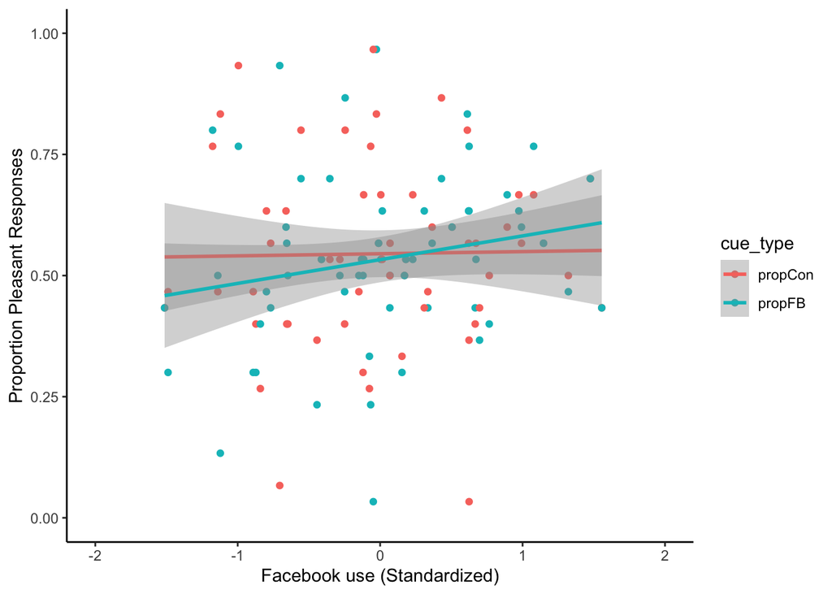

```r
# Fig 2 reproduced
library(ggplot2)

plot1 <- ggplot(data = df.final_tidy,
                mapping = aes(x = zfb_use_mean,
                              y = cue_prop,
                              color = cue_type)) +
        geom_point() +
        coord_cartesian(xlim = c(-2, 2), ylim = c(0,1)) +
        xlab("Facebook use (Standardized)") +
        ylab("Proportion Pleasant Responses") +
        scale_fill_discrete(name = "Cue Type", labels = c("Control", "Social Media") ) +
        geom_smooth(method = "lm") +
        theme_classic()

print(plot1)
```

Original Figure 2.

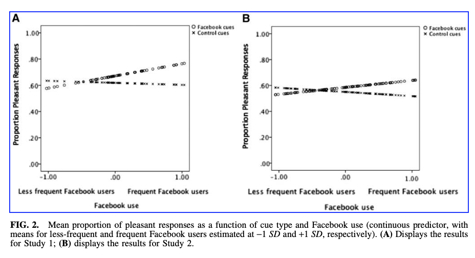

#The analyses as specified in the analysis plan.

```r
#1) Bivariate correlations between mean proportion of pleasant responses to FB cues, mean proportion of pleasant responses to control cues, Facebook use, and Facebook cravings

df.final_corr <- df.final_clean %>%
  dplyr::select(zfb_use_mean, propFB, propCon, cravings_mean)

corrtable <- cor(df.final_corr)
round(corrtable, 2)
```

```
##               zfb_use_mean propFB propCon cravings_mean
## zfb_use_mean          1.00   0.20    0.02          0.48
## propFB                0.20   1.00    0.12          0.09
## propCon               0.02   0.12    1.00         -0.22
## cravings_mean         0.48   0.09   -0.22          1.00
```

```r
print(corrtable)
```

```
##               zfb_use_mean    propFB     propCon cravings_mean
## zfb_use_mean    1.00000000 0.1968107  0.01740615     0.4770104
## propFB          0.19681072 1.0000000  0.12303017     0.0886115
## propCon         0.01740615 0.1230302  1.00000000    -0.2203141
## cravings_mean   0.47701038 0.0886115 -0.22031410     1.0000000
```

```r
#2) Mixed-model repeated-measures ANOVA on hedonic reactions with cue type as the within subjects factor (prop. of pleasant responses to FB cues, prop. of pleasant response to control cues) on standardized Facebook use as a continuous predictor.

library(lme4)
model1 <- lmer(data = df.final_tidy,
               cue_prop ~ cue_type*zfb_use_mean + (1| ID))

summary(model1)
```

```
## Linear mixed model fit by REML ['lmerMod']
## Formula: cue_prop ~ cue_type * zfb_use_mean + (1 | ID)
##    Data: df.final_tidy
##
## REML criterion at convergence: -49.5
##
## Scaled residuals:
##      Min       1Q   Median       3Q      Max
## -2.83776 -0.50922 -0.05204  0.47981  2.55080
##
## Random effects:
##  Groups   Name        Variance Std.Dev.
##  ID       (Intercept) 0.004122 0.06421
##  Residual             0.029683 0.17229
## Number of obs: 120, groups:  ID, 60
##
## Fixed effects:
##                              Estimate Std. Error t value
## (Intercept)                  0.545000   0.023737  22.960
## cue_typepropFB              -0.012222   0.031456  -0.389
## zfb_use_mean                 0.004395   0.032611   0.135
## cue_typepropFB:zfb_use_mean  0.044627   0.043215   1.033
##
## Correlation of Fixed Effects:
##             (Intr) c_tyFB zfb_s_
## cu_typprpFB -0.663
## zfb_use_men  0.000  0.000
## c_typpFB:__  0.000  0.000 -0.663
```

```r
anova(model1)
```

```
## Analysis of Variance Table
##                       Df   Sum Sq  Mean Sq F value
## cue_type               1 0.004481 0.004481  0.1510
## zfb_use_mean           1 0.035493 0.035493  1.1957
## cue_type:zfb_use_mean  1 0.031655 0.031655  1.0664
```

```r
#Role of gender?

model2 <- lmer(data = df.final_tidy,
               cue_prop ~ cue_type*zfb_use_mean*gender + (1| ID))

summary(model2)
```

```
## Linear mixed model fit by REML ['lmerMod']
## Formula: cue_prop ~ cue_type * zfb_use_mean * gender + (1 | ID)
##    Data: df.final_tidy
##
## REML criterion at convergence: -36.5
##
## Scaled residuals:
##      Min       1Q   Median       3Q      Max
## -2.72989 -0.44680 -0.05257  0.40163  2.43585
##
## Random effects:
##  Groups   Name        Variance Std.Dev.
##  ID       (Intercept) 0.004439 0.06662
##  Residual             0.029840 0.17274
## Number of obs: 120, groups:  ID, 60
##
## Fixed effects:
##                                    Estimate Std. Error t value
## (Intercept)                         0.57061    0.07289   7.829
## cue_typepropFB                     -0.12970    0.09617  -1.349
## zfb_use_mean                        0.05919    0.09899   0.598
## gender                             -0.01737    0.04863  -0.357
## cue_typepropFB:zfb_use_mean         0.02290    0.13061   0.175
## cue_typepropFB:gender               0.08270    0.06417   1.289
## zfb_use_mean:gender                -0.03947    0.06834  -0.578
## cue_typepropFB:zfb_use_mean:gender  0.01299    0.09017   0.144
##
## Correlation of Fixed Effects:
##             (Intr) c_tyFB zfb_s_ gender c_tFB:__ c_tFB: zfb__:
## cu_typprpFB -0.660
## zfb_use_men  0.016 -0.011
## gender      -0.944  0.623  0.007
## c_typpFB:__ -0.011  0.016 -0.660 -0.004
## c_typprpFB:  0.623 -0.944 -0.004 -0.660  0.007
## zfb_s_mn:gn  0.006 -0.004 -0.943 -0.032  0.622    0.021
## c_typFB:__: -0.004  0.006  0.622  0.021 -0.943   -0.032 -0.660
```

```r
anova(model1, model2)
```

```
## refitting model(s) with ML (instead of REML)
```

```
## Data: df.final_tidy
## Models:
## model1: cue_prop ~ cue_type * zfb_use_mean + (1 | ID)
## model2: cue_prop ~ cue_type * zfb_use_mean * gender + (1 | ID)
##        Df     AIC     BIC logLik deviance  Chisq Chi Df Pr(>Chisq)
## model1  6 -58.876 -42.152 35.438  -70.876
## model2 10 -53.535 -25.660 36.767  -73.535 2.6583      4     0.6165
```

```r
# No significant effect of gender, use model 1

#3) Simple effects tests to see if frequent Facebook users have more pleasant responses following FB cues than following control cues.

#install.packages("phia")
#library(phia)

#testInteractions(model1.anova,
#                 fixed= "df.final_tidy$cue_type",
#                 data = df.final_tidy)

#Because we did not find a significant interaction effect in our replication, we did not run the simple effects test that the original study did. However, the code to do so is included above and commented out.


#4) Mediation model using PROCESS macro Model 4 in SPSS. AMP responses were scored as a difference score by subtracting proportion of pleasant responses to control cues from proportion of pleasant responses to FB cues (higher scores mean more positive responses to FB cues relative to control cues). Facebook use will be entered as the predictor, AMP difference score as indirect mediation, and Facebook cravings will be the dependent variable.

library(mediation)
#total effect
fit.totaleffect = lm(cravings_mean ~ zfb_use_mean, df.final_clean)
summary(fit.totaleffect)
```

```
##
## Call:
## lm(formula = cravings_mean ~ zfb_use_mean, data = df.final_clean)
##
## Residuals:
##      Min       1Q   Median       3Q      Max
## -1.06792 -0.37864 -0.05729  0.33727  1.40338
##
## Coefficients:
##              Estimate Std. Error t value Pr(>|t|)
## (Intercept)   2.36667    0.07263  32.584  < 2e-16 ***
## zfb_use_mean  0.41245    0.09979   4.133 0.000117 ***
## ---
## Signif. codes:  0 '***' 0.001 '**' 0.01 '*' 0.05 '.' 0.1 ' ' 1
##
## Residual standard error: 0.5626 on 58 degrees of freedom
## Multiple R-squared:  0.2275, Adjusted R-squared:  0.2142
## F-statistic: 17.08 on 1 and 58 DF,  p-value: 0.0001165
```

```r
#IV on mediator
fit.mediator = lm(amp_diff ~ zfb_use_mean, df.final_clean)
summary(fit.mediator)
```

```
##
## Call:
## lm(formula = amp_diff ~ zfb_use_mean, data = df.final_clean)
##
## Residuals:
##      Min       1Q   Median       3Q      Max
## -0.91897 -0.08146 -0.00361  0.08415  0.91035
##
## Coefficients:
##              Estimate Std. Error t value Pr(>|t|)
## (Intercept)  -0.01222    0.03146  -0.389    0.699
## zfb_use_mean  0.04463    0.04321   1.033    0.306
##
## Residual standard error: 0.2437 on 58 degrees of freedom
## Multiple R-squared:  0.01805,    Adjusted R-squared:  0.001124
## F-statistic: 1.066 on 1 and 58 DF,  p-value: 0.306
```

```r
#mediator on DV
fit.meddv = lm(cravings_mean ~  amp_diff, df.final_clean)
summary(fit.meddv)
```

```
##
## Call:
## lm(formula = cravings_mean ~ amp_diff, data = df.final_clean)
##
## Residuals:
##     Min      1Q  Median      3Q     Max
## -0.8944 -0.4697 -0.1343  0.3129  1.4795
##
## Coefficients:
##             Estimate Std. Error t value Pr(>|t|)
## (Intercept)  2.37411    0.08045  29.510   <2e-16 ***
## amp_diff     0.60901    0.33236   1.832    0.072 .
## ---
## Signif. codes:  0 '***' 0.001 '**' 0.01 '*' 0.05 '.' 0.1 ' ' 1
##
## Residual standard error: 0.6224 on 58 degrees of freedom
## Multiple R-squared:  0.05472,    Adjusted R-squared:  0.03842
## F-statistic: 3.358 on 1 and 58 DF,  p-value: 0.07203
```

```r
#mediator on DV
fit.dv = lm(cravings_mean ~ zfb_use_mean + amp_diff, df.final_clean)
summary(fit.dv)
```

```
##
## Call:
## lm(formula = cravings_mean ~ zfb_use_mean + amp_diff, data = df.final_clean)
##
## Residuals:
##      Min       1Q   Median       3Q      Max
## -1.08551 -0.35187 -0.07036  0.34227  1.41597
##
## Coefficients:
##              Estimate Std. Error t value Pr(>|t|)
## (Intercept)   2.37217    0.07195  32.968  < 2e-16 ***
## zfb_use_mean  0.39236    0.09963   3.938 0.000226 ***
## amp_diff      0.45028    0.29997   1.501 0.138858
## ---
## Signif. codes:  0 '***' 0.001 '**' 0.01 '*' 0.05 '.' 0.1 ' ' 1
##
## Residual standard error: 0.5566 on 57 degrees of freedom
## Multiple R-squared:  0.2569, Adjusted R-squared:  0.2308
## F-statistic: 9.854 on 2 and 57 DF,  p-value: 0.0002112
```

```r
results = mediate(fit.mediator, fit.dv,
                  treat = "zfb_use_mean",
                  mediator = "amp_diff",
                  boot = T)
```

```
## Running nonparametric bootstrap
```

```r
summary(results)
```

```
##
## Causal Mediation Analysis
##
## Nonparametric Bootstrap Confidence Intervals with the Percentile Method
##
##                Estimate 95% CI Lower 95% CI Upper p-value
## ACME             0.0201      -0.0175         0.08    0.34
## ADE              0.3924       0.2025         0.57  <2e-16 ***
## Total Effect     0.4125       0.2228         0.59  <2e-16 ***
## Prop. Mediated   0.0487      -0.0536         0.18    0.34
## ---
## Signif. codes:  0 '***' 0.001 '**' 0.01 '*' 0.05 '.' 0.1 ' ' 1
##
## Sample Size Used: 60
##
##
## Simulations: 1000
```

### Exploratory analyses

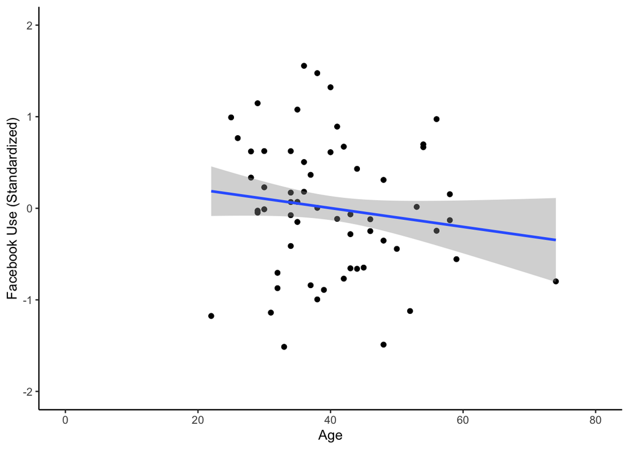

```r
#Exploratory analysis 1: Is there a relationship between age and FB use?
library(tidyverse)

df.final_tidy2 <- df.final_clean %>%
  dplyr::select(ID, propCon, propFB, zfb_use_mean, gender,cravings_mean, age) %>%
  pivot_longer(cols = -c(ID, zfb_use_mean, gender, cravings_mean,age),
               names_to = "cue_type",
               values_to = "cue_prop")

#visualize
plot_ex1 <- ggplot(data = df.final_tidy2,
                mapping = aes(x = age,
                              y = zfb_use_mean)) +
        geom_point() +
        coord_cartesian(xlim = c(0, 80), ylim = c(-2,2)) +
        xlab("Age") +
        ylab("Facebook Use (Standardized)") +
        geom_smooth(method = "lm") +
        theme_classic()

#Exploratory analysis 2: Is there a relationship between age and proportion of pleasant / nonpleasant responses to social media vs. control cues?

#visualize
plot_ex2 <- ggplot(data = df.final_tidy2,
                mapping = aes(x = age,
                              y = cue_prop,
                              color = cue_type)) +
        geom_point() +
        coord_cartesian(xlim = c(0, 80), ylim = c(0,1)) +
        xlab("Age") +
        ylab("Proportion Pleasant Responses") +
        scale_fill_discrete(name = "Cue Type", labels = c("Control", "Social Media") ) +
        geom_smooth(method = "lm") +
        theme_classic()

#Exploratory analysis 3: Is there a relationship between age and self-reported cravings for SM use?

#visualize
plot_ex3 <- ggplot(data = df.final_tidy2,
                mapping = aes(x = age,
                              y = cravings_mean)) +
        geom_point() +
        coord_cartesian(xlim = c(0, 80), ylim = c(0,5)) +
        xlab("Age") +
        ylab("Self-Reported Cravings for Social Media Use") +
        geom_smooth(method = "lm") +
        theme_classic()

plot_ex1
```

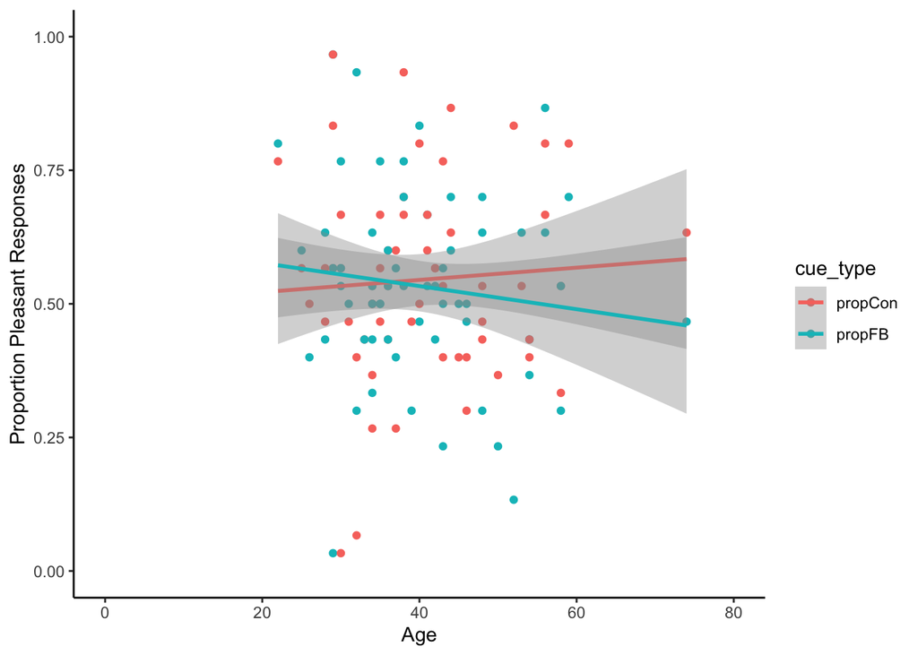

```r
plot_ex2
```

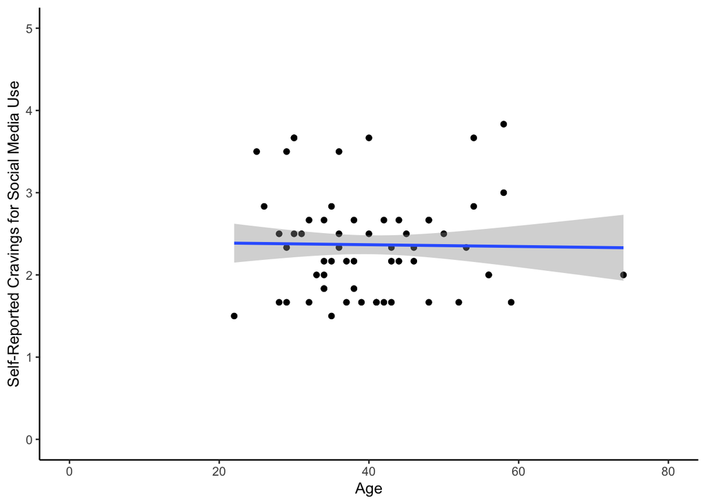

```r
plot_ex3
```

## Discussion

### Summary of Replication Attempt

The goal of the replication was to replicate the key finding from the original study: (1) A mixed-model repeated-measures ANOVA on hedonic reactions with cue type as the within-subjects factor on standardized FB use as a continuous predictor and (2) a mediation model with FB use as the predictor, AMP difference score (the proportion of pleasant responses to FB cues relative to control cues) as the mediator, and self-reported cravings for FB use as the dependent variable.

In the original study, they found Facebook use predicted AMP difference score, which had a direct effect on Facebook cravings. They found that the indirect effect by the AMP differnce score had a significant indirect effect of FB use on FB cravings by hedonic reactions to FB, with the mediator accounting for 6% of the total effect. Our replication partially replicated these results, but did not replicate the mediation findings.

In summary, we partially replicated the original findings of the total effect of Facebook Use on cravings but none of the other findings needed to demonstrate mediation. It should be noted, however, that our study was under-powered which may have influenced the results.

### Commentary

1. The exploratory analyses highlight an opportunity to investigate the potential role of age in Facebook use, spontaneous hedonic responses to social media cues, and self-reported cravings. From visualizations, it appears that older people tend to use FB less and have more negative responses to social media cues relative to control. Something I would like to do in my own future research is to expand on this AMP task to see if people’s beliefs or mindsets about the enhancing vs. harmful nature of social media may influence their spontaneous hedonic reactions.
2. I felt that the meaning of this partial replication is ddifficult to parse. I think that the under-powered sample size limits our ability to draw conclusions about our replication results.
3. No challenges raised; did not hear back from authors.